# Cloud-Based Logger

[*Effecten van luchtkwaliteit op de gezondheid in accommodaties van schepen (ELGAS)* - TETRA-project HBC.2019.2033](https://www.kdg.be/ELGAS)

Copyright (c) 2021

Permission is hereby granted, free of charge, to any person obtaining a copy of this software and associated documentation files (the "Software"), to deal in the Software without restriction, including without limitation the rights to use, copy, modify, merge, publish, distribute, sublicense, and/or sell copies of the Software, and to permit persons to whom the Software is furnished to do so, subject to the following conditions:

The above copyright notice and this permission notice shall be included in all copies or substantial portions of the Software.

THE SOFTWARE IS PROVIDED "AS IS", WITHOUT WARRANTY OF ANY KIND, EXPRESS OR IMPLIED, INCLUDING BUT NOT LIMITED TO THE WARRANTIES OF MERCHANTABILITY, FITNESS FOR A PARTICULAR PURPOSE AND NON INFRINGEMENT. IN NO EVENT SHALL THE AUTHORS OR COPYRIGHT HOLDERS BE LIABLE FOR ANY CLAIM, DAMAGES OR OTHER LIABILITY, WHETHER IN AN ACTION OF CONTRACT, TORT OR OTHERWISE, ARISING FROM, OUT OF OR IN CONNECTION WITH THE SOFTWARE OR THE USE OR OTHER DEALINGS IN THE SOFTWARE.

```python
import warnings
warnings.filterwarnings('ignore')
```

```python
from IPython.display import Image
```

[figure not shown]

```python
Image("./img/IoT_System.PNG")
```

Carbon dioxide (CO2) is an indicator of indoor air quality. The CO2 content of the air should, ideally, not exceed 900 ppm and under no circumstances should exceed 1200 ppm. Let us take this as an example use case for our Cloud-Based Data Logger.

[figure not shown]

```python
Image("./img/CO2 chart.PNG")
```

## Serial Test

```python
def read_serial(com_port, baud_rate):
    ser = serial.Serial(com_port, baud_rate, bytesize=8, parity='N',\
                        stopbits=1, timeout=1)
    ser.flush()
    ser.write(bytes(b"s"))
    time.sleep(2) # wait two seconds, the default configuration is used where SCD30 has data ready every two seconds.

    data = ser.read(24)
    ser.close()
    return data
```

```python
import serial
import time

COM_PORT = 'com14'
BAUD_RATE = '115200'

sample = read_serial(COM_PORT, BAUD_RATE)
print(sample)
```

```
b'OK,12,24.0,55,484,X\r\n'
```

```python
for _ in range(10):
    print(read_serial(COM_PORT, BAUD_RATE))
```

```
b'OK,13,24.0,55,484,X\r\n'
b'OK,14,24.1,55,484,X\r\n'
b'OK,15,24.1,55,484,X\r\n'
b'OK,16,24.1,55,485,X\r\n'
b'OK,17,24.1,55,486,X\r\n'
b'OK,18,24.1,55,486,X\r\n'
b'OK,19,24.1,55,485,X\r\n'
b'OK,20,24.1,55,485,X\r\n'
b'OK,21,24.1,55,484,X\r\n'
b'OK,22,24.1,55,485,X\r\n'
```

### Create assets on AllThingsTalk Maker

```python
def create_assets(device_file):
    """
    Create the assets on a ground

    Parameters
    ----------
    device_file: str
        device json file

    Returns
    -------
    asset_list: list
        list of created assets

    Example
    -------
    >>> import json
    >>> import requests
    >>> asset_list = create_assets("device.json")
    """

    with open(device_file) as json_file:
        device = json.load(json_file)

    url = "https://"+device["device"]["authentication"]["api"]\
            +"/device/"+device["device"]["authentication"]["Device_ID"]\
            +"/assets"

    asset_list = []

    for asset_nmb in range(len(device["device"]["assets"])):
        asset = 'asset#' + str(asset_nmb)

        payload = {
            "name": device["device"]["assets"][asset]["name"],
            "title": device["device"]["assets"][asset]["title"],
            "description": device["device"]["assets"][asset]["description"],
            "is": device["device"]["assets"][asset]["kind"],
            "profile": device["device"]["assets"][asset]["profile"]
        }

        headers = {
            'Content-Type': 'application/json',
            'Authorization': device["device"]["authentication"]["Ground_Token"]
        }

        response = requests.request("POST", url, headers=headers,\
                                    data=str(payload), timeout=10)
        asset_list.append(response.json())

    return asset_list
```

```python
import json
import requests

asset_list = create_assets("device.json")
```

### Send Indoor AQ Data to the Cloud

```python
def read_serial(com_port, baud_rate):
    ser = serial.Serial(com_port, baud_rate, bytesize=8, parity='N',\
                        stopbits=1, timeout=1)
    ser.flush()
    ser.write(bytes(b"s"))
    time.sleep(2) # wait two seconds, the default configuration is used where SCD30 has data ready every two seconds.

    data = ser.read(24)
    ser.close()
    return data


def send_data(device, timestamp, sensor_data):
    """
    Sample the sensor data and send to the Cloud.

    Parameters
    ----------
    device: type dict
        device description (defined in a json file)
    timestamp: type str
        UTC time
    sensor_data: type list
        ['OK', counter, Temperature_degC, Humidity_perc, CO2_ppm, 'X\r\n']

    Returns
    -------
    message: str
        ConnectionOK: data is send successful
        ConnectionError: a Connection error occurred. (https://docs.python-requests.org/en/master/_modules/requests/exceptions/)
        HTTPError: an HTTP error occurred (https://docs.python-requests.org/en/master/_modules/requests/exceptions/)
    """

    url = "https://"+device["device"]["authentication"]["api"]\
            +"/device/"+device["device"]["authentication"]["Device_ID"]\
            +"/state"

    headers = {
        'Content-Type': 'application/json',
        'Authorization': device["device"]["authentication"]["Ground_Token"]
    }

    payload = {
        device["device"]["assets"]["asset#0"]["name"]:
            {"value": sensor_data[1],
             "at": timestamp},
        device["device"]["assets"]["asset#1"]["name"]:
            {"value": sensor_data[2],
             "at": timestamp},
        device["device"]["assets"]["asset#2"]["name"]:
            {"value": sensor_data[3],
             "at": timestamp},
        device["device"]["assets"]["asset#3"]["name"]:
            {"value": sensor_data[4],
             "at": timestamp}
    }

    try:
        response = requests.request("PUT", url, headers=headers, json=payload,\
                                    timeout=int(device["device"]["authentication"]["timeout"]))
        response.raise_for_status()
        message = 'ok'
        return message
    except requests.exceptions.ConnectionError as exception:
        message = 'ConnectionError'
        return message
    except requests.exceptions.HTTPError as exception:
        message = 'HTTPError'
        return message
```

```python
import time
import datetime
import json
import requests
import serial

with open('device.json') as json_file:
    device = json.load(json_file)

# Time between two samples
SAMPLING_TIME = 20

# Read 10 samples and send the output to the Cloud
for i in range(10):
    start_sample = time.perf_counter()

    timestamp = datetime.datetime.utcnow().isoformat()
    sensor_data = read_serial(device["device"]["serial"]["com_port"],\
                              device["device"]["serial"]["baud_rate"]).decode("utf-8").split(',')
    response = send_data(device, timestamp, sensor_data)

    print('sample:',i, ' - ', timestamp,' - ', sensor_data, ' - ', response)

    finish_sample = time.perf_counter()
    time.sleep(int(SAMPLING_TIME) - int(round(finish_sample - start_sample, 2)))
```

```
sample: 0  -  2021-09-13T07:06:07.021061  -  ['OK', '23', '24.1', '55', '484', 'X\r\n']  -  ok
sample: 1  -  2021-09-13T07:06:27.375055  -  ['OK', '24', '24.2', '54', '482', 'X\r\n']  -  ok
sample: 2  -  2021-09-13T07:06:47.635579  -  ['OK', '25', '24.3', '54', '481', 'X\r\n']  -  ok
sample: 3  -  2021-09-13T07:07:07.879568  -  ['OK', '26', '24.3', '54', '481', 'X\r\n']  -  ok
sample: 4  -  2021-09-13T07:07:28.120851  -  ['OK', '27', '24.4', '54', '478', 'X\r\n']  -  ok
sample: 5  -  2021-09-13T07:07:48.367170  -  ['OK', '28', '24.4', '54', '476', 'X\r\n']  -  ok
sample: 6  -  2021-09-13T07:08:08.689969  -  ['OK', '29', '24.4', '53', '475', 'X\r\n']  -  ok
sample: 7  -  2021-09-13T07:08:28.952663  -  ['OK', '30', '24.5', '53', '474', 'X\r\n']  -  ok
sample: 8  -  2021-09-13T07:08:49.209562  -  ['OK', '31', '24.5', '53', '472', 'X\r\n']  -  ok
sample: 9  -  2021-09-13T07:09:09.449161  -  ['OK', '32', '24.5', '53', '472', 'X\r\n']  -  ok
```

**An example of the data shown on the Pinboard.**

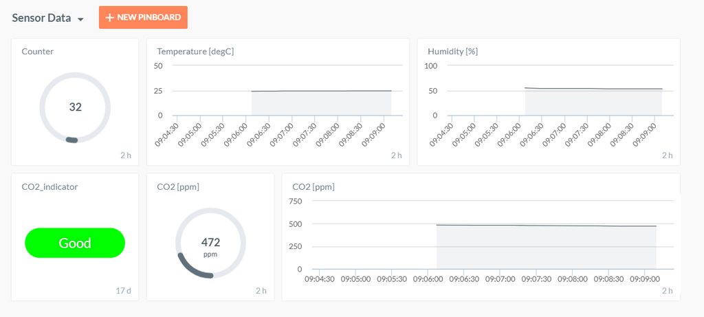

```python
Image("./img/Jupyter Notebook/Send Indoor AQ Data to the Cloud.PNG")
```

### Retrieve data from Cloud

```python
def _get_cloud_asset_data(device, time_from, time_to, asset_name, pagenmb):

    """
    Retrieves paged collection of historical asset states within provided time range.
    https://api.allthingstalk.io/swagger/ui/index#operation/AssetStates_GetAssetHistoricalStates

    Parameters
    ----------
    device: type dict
        device description (defined in a json file)
    time_from: str
        start time, ex. 2020-09-08T00:00:00 (iso8601 format)
    time_to: str
        end time, ex. 2020-09-08T23:59:59 (iso8601 format)
    pagenmb: int
        Page in the result set

    Returns
    -------
    response.json()['data']:

    """

    url = "https://"+device["device"]["authentication"]["api"]+\
    "/device/"+device["device"]["authentication"]["Device_ID"]+\
    "/asset/"+asset_name+"/states?from="+time_from+"&to="+time_to+"&page"+str(pagenmb)

    payload = {}

    headers = {
        'Authorization': device["device"]["authentication"]["Ground_Token"],
        'Content-Type': 'application/json'
    }

    response = requests.request("GET", url, headers=headers, data = payload)

    return response.json()['data']


def _fill_missing_data(timestamp, data):
    k = 0
    new_data = []

    for i in range(len(timestamp)):
        if timestamp[i] == data[k]['at']:
            new_data.append(data[k])
            k = k + 1
        else:
            new_data.append({'at': timestamp[i], 'data': -666})

    return new_data


def _get_timestamps(cloud_data):
    length = []
    for i in range(len(cloud_data)):
        length.append(len(cloud_data[i]))
    pos_max_value = length.index(max(length))

    timestamp = []
    for i in range(max(length)):
        timestamp.append(cloud_data[pos_max_value][i]['at'])
    return timestamp


def cloud_data_to_df(device, time_from, time_to):
    """
    Retrieve Cloud data and translate it to a pandas dataframe
    Raw data from the assets: Counter, Temperature_degC, Humidity_perc, CO2_ppm

    Important:
    ----------
    - take max. 24h or 1 day
    - time in UTC - ISO 8601 Format

    Parameters
    ----------
    device: type dict
        device description (defined in a json file)
    time_from: str
        start time, ex. 2020-09-08T00:00:00 (iso8601 format)
    time_to: str
        end time, ex. 2020-09-08T23:59:59 (iso8601 format)

    Returns
    -------
    cloud_data_df: df
        a pandas dataframe is returned

    Example
    -------
    >>> import json
    >>> import pandas as pd

    """

    columns = ['time']
    for asset_nmb in range(len(device["device"]["assets"])):
        asset = 'asset#' + str(asset_nmb)
        columns.append(device["device"]["assets"][asset]["name"])

    cloud_data_df = pd.DataFrame(index=range(0), columns=columns)

    asset_name = []
    asset_unit = []

    for asset_nmb in range(len(device["device"]["assets"])):
        asset = 'asset#' + str(asset_nmb)
        asset_name.append(device["device"]["assets"][asset]["name"])
        asset_unit.append(device["device"]["assets"][asset]["profile"]["unit"])

    cloud_data = []
    for name in asset_name:
        cloud_data.append(_get_cloud_asset_data(device, time_from, time_to, name, 0))

    # ------------------------------------------------------------------------------------------------------------------
    new_cloud_data = []
    for i in range(len(cloud_data)):
        new_cloud_data.append(_fill_missing_data(_get_timestamps(cloud_data), cloud_data[i]))
    cloud_data = new_cloud_data
    # ------------------------------------------------------------------------------------------------------------------

    for k in range(len(cloud_data[0])):
        date_time_str = cloud_data[0][k]['at'][0:10] + ' ' + cloud_data[0][k]['at'][11:19]
        sample = {'time': datetime.datetime.strptime(date_time_str, '%Y-%m-%d %H:%M:%S'),
                  asset_name[0]: int(cloud_data[0][k]['data']),
                  asset_name[1]: float(cloud_data[1][k]['data']),
                  asset_name[2]: float(cloud_data[2][k]['data']),
                  asset_name[3]: int(cloud_data[3][k]['data']),
                  }
        cloud_data_df = cloud_data_df.append(sample, ignore_index=True)

    return cloud_data_df
```

```python
# data samples
import numpy as np
import matplotlib.pyplot as plt

# 10 samples
nmb_samples = 10
Temp_degC = np.linspace(10, 150, num=nmb_samples)
Hum_perc = np.linspace(10, 100, num=nmb_samples)
CO2_ppm = np.linspace(0, 2500, num=nmb_samples)


fig, (ax1, ax2, ax3) = plt.subplots(1, 3, figsize=(15,5))
ax1.set(xlabel='sample', ylabel='Temperature [°C]')
ax1.plot(Temp_degC, 'ro')
ax1.grid()
ax2.set(xlabel='sample', ylabel='Humidity [%]')
ax2.plot(Hum_perc, 'ro')
ax2.grid()
ax3.set(xlabel='sample', ylabel='$CO_{2}$ [ppm]')
ax3.plot(CO2_ppm, 'ro')
ax3.grid()
fig.tight_layout()
```

[output not shown]

```python
import time
import datetime
import json
import requests
import serial

with open('device.json') as json_file:
    device = json.load(json_file)

# Time between two samples
SAMPLING_TIME = 20
nmb_samples = 10

# send data to the Cloud
for i in range(nmb_samples):
    start_sample = time.perf_counter()

    timestamp = datetime.datetime.utcnow().isoformat()
    sensor_data = ['OK', str(i), str(round(Temp_degC[i],1)), str(int(Hum_perc[i])), str(int(CO2_ppm[i])), 'X\r\n']

    response = send_data(device, timestamp, sensor_data)

    print('sample:',i, ' - ', timestamp,' - ', sensor_data, ' - ', response)

    finish_sample = time.perf_counter()
    time.sleep(int(SAMPLING_TIME) - int(round(finish_sample - start_sample, 2)))
```

```
sample: 0  -  2021-09-13T07:14:16.928627  -  ['OK', '0', '10.0', '10', '0', 'X\r\n']  -  ok
sample: 1  -  2021-09-13T07:14:37.210262  -  ['OK', '1', '25.6', '20', '277', 'X\r\n']  -  ok
sample: 2  -  2021-09-13T07:14:57.451337  -  ['OK', '2', '41.1', '30', '555', 'X\r\n']  -  ok
sample: 3  -  2021-09-13T07:15:17.666737  -  ['OK', '3', '56.7', '40', '833', 'X\r\n']  -  ok
sample: 4  -  2021-09-13T07:15:37.911003  -  ['OK', '4', '72.2', '50', '1111', 'X\r\n']  -  ok
sample: 5  -  2021-09-13T07:15:58.118392  -  ['OK', '5', '87.8', '60', '1388', 'X\r\n']  -  ok
sample: 6  -  2021-09-13T07:16:18.362445  -  ['OK', '6', '103.3', '70', '1666', 'X\r\n']  -  ok
sample: 7  -  2021-09-13T07:16:38.590313  -  ['OK', '7', '118.9', '80', '1944', 'X\r\n']  -  ok
sample: 8  -  2021-09-13T07:16:58.822756  -  ['OK', '8', '134.4', '90', '2222', 'X\r\n']  -  ok
sample: 9  -  2021-09-13T07:17:19.093498  -  ['OK', '9', '150.0', '100', '2500', 'X\r\n']  -  ok
```

**An example of the data shown on the Pinboard.**

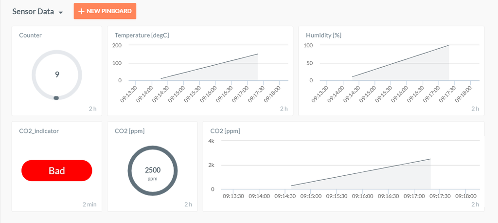

```python
Image("./img/Jupyter Notebook/Retrieve data from Cloud.PNG")
```

```python
import json
import pandas as pd

with open('device.json') as json_file:
    device = json.load(json_file)

time_from = '2021-09-13T07:14:16'
time_to = '2021-09-13T07:17:20'

cloud_data_df = cloud_data_to_df(device, time_from, time_to)
cloud_data_df.head(10)
```

|  | time | Counter | Temperature_degC | Humidity_perc | CO2_ppm |
| --- | --- | --- | --- | --- | --- |
| 0 | 2021-09-13 07:14:16 | 0 | 10.0 | 10.0 | 0 |
| 1 | 2021-09-13 07:14:37 | 1 | 25.6 | 20.0 | 277 |
| 2 | 2021-09-13 07:14:57 | 2 | 41.1 | 30.0 | 555 |
| 3 | 2021-09-13 07:15:17 | 3 | 56.7 | 40.0 | 833 |
| 4 | 2021-09-13 07:15:37 | 4 | 72.2 | 50.0 | 1111 |
| 5 | 2021-09-13 07:15:58 | 5 | 87.8 | 60.0 | 1388 |
| 6 | 2021-09-13 07:16:18 | 6 | 103.3 | 70.0 | 1666 |
| 7 | 2021-09-13 07:16:38 | 7 | 118.9 | 80.0 | 1944 |
| 8 | 2021-09-13 07:16:58 | 8 | 134.4 | 90.0 | 2222 |
| 9 | 2021-09-13 07:17:19 | 9 | 150.0 | 100.0 | 2500 |

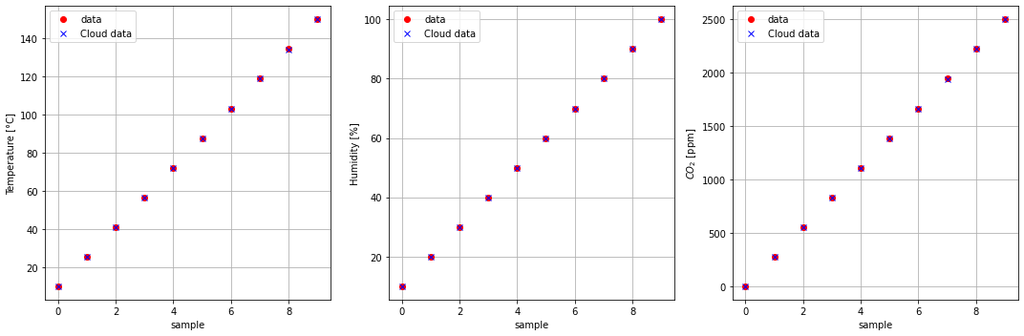

```python
fig, (ax1, ax2, ax3) = plt.subplots(1, 3, figsize=(15,5))
ax1.set(xlabel='sample', ylabel='Temperature [°C]')
ax1.plot(Temp_degC, 'ro', label='data')
ax1.plot(cloud_data_df['Temperature_degC'], 'bx', label='Cloud data')
ax1.grid()
ax1.legend()

ax2.set(xlabel='sample', ylabel='Humidity [%]')
ax2.plot(Hum_perc, 'ro', label='data')
ax2.plot(cloud_data_df['Humidity_perc'], 'bx', label='Cloud data')
ax2.grid()
ax2.legend()

ax3.set(xlabel='sample', ylabel='$CO_{2}$ [ppm]')
ax3.plot(CO2_ppm, 'ro', label='data')
ax3.plot(cloud_data_df['CO2_ppm'], 'bx', label='Cloud data')
ax3.grid()
ax3.legend()
fig.tight_layout()
```

### Rules

```python
def decoder(num_values):
    value_cat = []
    for num_label in num_values:
        if num_label >= 1200:
            value_cat.append('Bad')
        elif num_label >= 900:
            value_cat.append('Moderate')
        else:
            value_cat.append('Good')
    return value_cat


def send_asset_data_to_cloud(device, asset_name, payload_timestamp, payload_value):
    """
    Send a a value to an asset

    Parameters
    ----------
    device: type dict
        device description (defined in a json file)
    asset_name: str
        name of the assets
    payload_timestamp: str
        timestamp
    payload_value:
        payload value

    Returns
    -------
    message: str
        ConnectionOK: data is send successful
        ConnectionError: a Connection error occurred. (https://docs.python-requests.org/en/master/_modules/requests/exceptions/)
        HTTPError: an HTTP error occurred (https://docs.python-requests.org/en/master/_modules/requests/exceptions/)

    """

    headers = {
        'Content-Type': 'application/json',
        'Authorization': device["device"]["authentication"]["Ground_Token"]
    }

    # https://api.allthingstalk.io/swagger/ui/index
    url = "https://"+device["device"]["authentication"]["api"]+\
    "/device/"+device["device"]["authentication"]["Device_ID"]+\
    "/state"

    payload = {
        asset_name: {
            "value": payload_value,
            "at": payload_timestamp
        }
    }

    try:
        response = requests.request("PUT", url, headers=headers, json=payload)
        response.raise_for_status()
        message = 'ConnectionOK'
        return message
    except requests.exceptions.ConnectionError as exception:
        message = 'ConnectionError'
        return message
    except requests.exceptions.HTTPError as exception:
        message = 'HTTPError'
        return message


def get_asset_data_from_cloud(device, asset_name, payload_timestamp):
    """
    Obtain asset data from the Cloud

    Parameters
    ----------
    device: type dict
        device description (defined in a json file)
    asset_name: str
        name of the assets
    payload_timestamp: str
        timestamp

    Returns
    -------
    message: str or float
        data: the asset data
        ConnectionError: a Connection error occurred. (https://docs.python-requests.org/en/master/_modules/requests/exceptions/)
        HTTPError: an HTTP error occurred (https://docs.python-requests.org/en/master/_modules/requests/exceptions/)

    """

    # https://api.allthingstalk.io/swagger/ui/index
    url = "https://"+device["device"]["authentication"]["api"]\
    +"/device/"+device["device"]["authentication"]["Device_ID"]\
    +"/asset/"+asset_name+"/states?from="+payload_timestamp+"&page0"

    payload = {}
    headers = {
        'Authorization': device["device"]["authentication"]["Ground_Token"],
        'Content-Type': 'application/json'
    }

    try:
        response = requests.request("GET", url, headers=headers, data = payload)
        response.raise_for_status()
        return response.json()['data']
    except requests.exceptions.ConnectionError as exception:
        message = 'ConnectionError'
        return message
    except requests.exceptions.HTTPError as exception:
        message = 'HTTPError'
        return message
```

```python
import datetime
import time
import json
import requests

with open('device.json') as json_file:
    device = json.load(json_file)

asset_name = 'CO2_ppm'

print('------------------')
print('Asset:',asset_name)
print('------------------')

start_datetime = datetime.datetime.utcnow().isoformat()

# Create a random list of payload values (risk values) between 1 and 10 (10 inclusive)
from random import randrange

payload = []
data_from_cloud = []
timestamp = []
label_from_cloud = []
value_from_cloud = []

payload = [1250,950,400,950,1250,950,400]
print('Payload:', payload)
print('Payload label:', decoder(payload))

# send & retrieve risk data
for value in payload:
    payload_timestamp = datetime.datetime.utcnow().isoformat()
    timestamp.append(payload_timestamp)
    print('Time:', payload_timestamp, '- Value:', value, ',- Label:', decoder([value]))

    # Send data
    send_asset_data_to_cloud(device, asset_name, payload_timestamp, value)
    time.sleep(5)

    # Retrieve data
    data_from_cloud.append(get_asset_data_from_cloud(device, asset_name, payload_timestamp))
    time.sleep(5)

print('------------------')
print('Data from Cloud.')
print('------------------')

data_from_cloud
```

```
------------------
Asset: CO2_ppm
------------------
Payload: [1250, 950, 400, 950, 1250, 950, 400]
Payload label: ['Bad', 'Moderate', 'Good', 'Moderate', 'Bad', 'Moderate', 'Good']
Time: 2021-09-13T07:22:47.981742 - Value: 1250 ,- Label: ['Bad']
Time: 2021-09-13T07:22:58.381068 - Value: 950 ,- Label: ['Moderate']
Time: 2021-09-13T07:23:08.757675 - Value: 400 ,- Label: ['Good']
Time: 2021-09-13T07:23:19.137324 - Value: 950 ,- Label: ['Moderate']
Time: 2021-09-13T07:23:29.490756 - Value: 1250 ,- Label: ['Bad']
Time: 2021-09-13T07:23:39.845483 - Value: 950 ,- Label: ['Moderate']
Time: 2021-09-13T07:23:50.211019 - Value: 400 ,- Label: ['Good']
------------------
Data from Cloud.
------------------
```

```
[[{'at': '2021-09-13T07:22:47.981Z', 'data': 1250}],
 [{'at': '2021-09-13T07:22:58.381Z', 'data': 950}],
 [{'at': '2021-09-13T07:23:08.757Z', 'data': 400}],
 [{'at': '2021-09-13T07:23:19.137Z', 'data': 950}],
 [{'at': '2021-09-13T07:23:29.49Z', 'data': 1250}],
 [{'at': '2021-09-13T07:23:39.845Z', 'data': 950}],
 [{'at': '2021-09-13T07:23:50.211Z', 'data': 400}]]
```

**An example of the data shown on the Pinboard.**

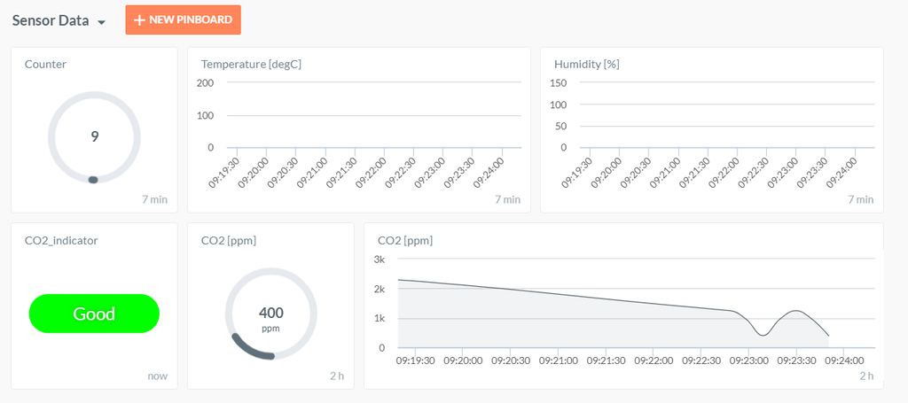

```python
Image("./img/Jupyter Notebook/Rules.PNG")
```